# Artificial Intelligence: Identify Fraud from Enron Email

### Data Exploration

```python
from IPython.display import HTML

HTML('''<script>
code_show=true;
function code_toggle() {
 if (code_show){
 $('div.input').hide();
 } else {
 $('div.input').show();
 }
 code_show = !code_show
}
$( document ).ready(code_toggle);
</script>
<form action="javascript:code_toggle()"><input type="submit" value="Click here to toggle on/off the raw code."></form>''')
```

```python
import sys
import pickle
sys.path.append("../tools/")
from feature_format import featureFormat, targetFeatureSplit
from tester import dump_classifier_and_data
from sklearn.preprocessing import MinMaxScaler, StandardScaler
from sklearn.feature_selection import SelectKBest, f_classif
from sklearn.tree import DecisionTreeClassifier
from sklearn.naive_bayes import GaussianNB
from sklearn.pipeline import Pipeline
from sklearn.cross_validation import train_test_split,StratifiedShuffleSplit
from sklearn.grid_search import GridSearchCV
from sklearn.neighbors import KNeighborsClassifier
from sklearn.decomposition import PCA
from sklearn.svm import SVC
from sklearn.metrics import accuracy_score


### Load the dictionary containing the dataset
with open("final_project_dataset.pkl", "r") as data_file:
    data_dict = pickle.load(data_file)
```

```python
a = 0
x = 0
i = 0
count = 0
count2 = 0
count3 = 0
for employee in data_dict:
    for feature, feature_value in data_dict[employee].iteritems():
        i +=1
        if feature_value =="NaN":
            x +=1
        if feature == "poi":
            count +=1
            if feature_value == True:
                count2 +=1
            if feature_value == False:
                count3 +=1


print "Total number of data points: ",i
print "Count of people in dataset: ", count
print "Count of POI's: ",count2
print "Count of non-POI's: ", count3
print "Number of missing values: ", x
print "Number of usable points: ", i-x
```

```
Total number of data points:  3066
Count of people in dataset:  146
Count of POI's:  18
Count of non-POI's:  128
Number of missing values:  1358
Number of usable points:  1708
```

### Available fields

```python
for employee in data_dict:
    for feature, feature_value in data_dict[employee].iteritems():
        print feature
    break
```

```
salary
to_messages
deferral_payments
total_payments
exercised_stock_options
bonus
restricted_stock
shared_receipt_with_poi
restricted_stock_deferred
total_stock_value
expenses
loan_advances
from_messages
other
from_this_person_to_poi
poi
director_fees
deferred_income
long_term_incentive
email_address
from_poi_to_this_person
```

### Amount of missing values in each field

```python
import math
nan_counts = {}

for employee in data_dict:
    for feature, feature_value in data_dict[employee].iteritems():
        if feature_value =="NaN":
            if feature in nan_counts:
                nan_counts[feature] += 1
            else:
                nan_counts[feature] = 1
nan_counts
```

```
{'bonus': 64,
 'deferral_payments': 107,
 'deferred_income': 97,
 'director_fees': 129,
 'email_address': 35,
 'exercised_stock_options': 44,
 'expenses': 51,
 'from_messages': 60,
 'from_poi_to_this_person': 60,
 'from_this_person_to_poi': 60,
 'loan_advances': 142,
 'long_term_incentive': 80,
 'other': 53,
 'restricted_stock': 36,
 'restricted_stock_deferred': 128,
 'salary': 51,
 'shared_receipt_with_poi': 60,
 'to_messages': 60,
 'total_payments': 21,
 'total_stock_value': 20}
```

## Outlier Investigation

### Salary and Bonus Investigated

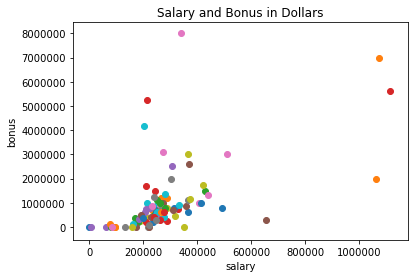

```python
import matplotlib.pyplot
from feature_format import featureFormat, targetFeatureSplit

features = ["salary","bonus"]

data = featureFormat(data_dict, features)


for point in data:
    salary = point[0]
    bonus = point[1]
    matplotlib.pyplot.scatter(salary,bonus)
matplotlib.pyplot.xlabel("salary")
matplotlib.pyplot.ylabel("bonus")
matplotlib.pyplot.title("Salary and Bonus in Dollars")
matplotlib.pyplot.show()
```

I noticed there were two salaries that were close to 0.

```python
for employee in data_dict:
    for features, feature_value in data_dict[employee].iteritems():
        if feature_value <> "NaN":
            if features == "salary" and feature_value < 10000:
                print employee, feature_value
```

```
BANNANTINE JAMES M 477
GRAY RODNEY 6615
```

These two salaries are obviously less than what a normal yearly salary is, so I'll remove the points from the dataset. After that I looked at the highest values, with a bonus over 8 million dollars or a salary over 600,000 dollars. I believe these values are important for the analysis, so I won't remove them.

```python
data_dict.pop("TOTAL",0)
data_dict.pop("BANNANTINE JAMES M", 0)
data_dict.pop("GRAY RODNEY", 0)

for employee in data_dict:
    for features, feature_value in data_dict[employee].iteritems():
        if feature_value <> "NaN":
            if features =="bonus" and feature_value >5000000:
                print employee, features, feature_value
            if features == "salary" and feature_value > 600000:
                print employee, features, feature_value
```

```
LAVORATO JOHN J bonus 8000000
LAY KENNETH L salary 1072321
LAY KENNETH L bonus 7000000
BELDEN TIMOTHY N bonus 5249999
SKILLING JEFFREY K salary 1111258
SKILLING JEFFREY K bonus 5600000
PICKERING MARK R salary 655037
FREVERT MARK A salary 1060932
```

### Emails To/From a Person of Interest Investigated

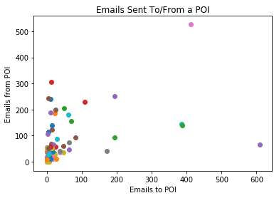

```python
features = ["from_this_person_to_poi","from_poi_to_this_person"]

data = featureFormat(data_dict, features)

for point in data:
    from_this_person_to_poi = point[0]
    from_poi_to_this_person = point[1]
    matplotlib.pyplot.scatter(from_this_person_to_poi,from_poi_to_this_person)
matplotlib.pyplot.xlabel("Emails to POI")
matplotlib.pyplot.ylabel("Emails from POI")
matplotlib.pyplot.title("Emails Sent To/From a POI")
matplotlib.pyplot.show()
```

I looked up the amount of employees that had 0 emails to a POI and found a decent amount. Unlike the low salary outliers, which I had to remove, it's understandable that some people may have not been in communcation with a POI. Also, with this many people, it's less probable that they can all be outliers.

```python
print "No messages from this person to POI:"
for employee in data_dict:
    for features, feature_value in data_dict[employee].iteritems():
        if features=="from_this_person_to_poi":
            if feature_value == 0 and feature_value <> "NaN":
                print employee
```

```
No messages from this person to POI:
CORDES WILLIAM R
MEYER ROCKFORD G
UMANOFF ADAM S
GIBBS DANA R
MULLER MARK S
WALLS JR ROBERT H
BERGSIEKER RICHARD P
LEWIS RICHARD
HAYES ROBERT E
POWERS WILLIAM
MCCLELLAN GEORGE
MORAN MICHAEL P
THORN TERENCE H
FOY JOE
PICKERING MARK R
FOWLER PEGGY
BUCHANAN HAROLD G
MARTIN AMANDA K
TAYLOR MITCHELL S
```

Outlier employees with 300 emails to or from a POI.

```python
for employee in data_dict:
    for features, feature_value in data_dict[employee].iteritems():
        if features=="from_this_person_to_poi" or features =="from_poi_to_this_person":
            if feature_value > 300 and feature_value <> "NaN":
                print employee, features, feature_value
```

```
BECK SALLY W from_this_person_to_poi 386
LAVORATO JOHN J from_this_person_to_poi 411
LAVORATO JOHN J from_poi_to_this_person 528
DELAINEY DAVID W from_this_person_to_poi 609
KEAN STEVEN J from_this_person_to_poi 387
DIETRICH JANET R from_poi_to_this_person 305
```

## Optimize Feature Selection/Engineering

### Features Created

#### Fraction from POI

This feature divides the messages received from a POI by the total messages received.

#### Total POI emails

This feature adds messages sent from a POI to the employee, and messages from the employee to a POI.

```python
def computeFraction( poi_messages, all_messages ):
    """ given a number messages to/from POI (numerator)
        and number of all messages to/from a person (denominator),
        return the fraction of messages to/from that person
        that are from/to a POI
   """
    fraction = 0.
    if poi_messages == "NaN" or all_messages == "NaN" or all_messages == "0.":
        fraction = 0.
    else:
        fraction = float(poi_messages) / float(all_messages)
    return fraction

for name in data_dict:

    data_point = data_dict[name]

    #first fraction
    from_poi_to_this_person = data_point["from_poi_to_this_person"]
    to_messages = data_point["to_messages"]
    if from_poi_to_this_person != 'NaN' and to_messages != 'NaN' and to_messages != 0:
        fraction_from_poi = computeFraction( from_poi_to_this_person, to_messages )
    else:
        fraction_from_poi = computeFraction( from_poi_to_this_person, to_messages )

    #second fraction
    from_this_person_to_poi = data_point["from_this_person_to_poi"]
    from_messages = data_point["from_messages"]
    if from_this_person_to_poi != 'NaN' and from_messages != 'NaN' and from_messages != 0:
        fraction_to_poi = computeFraction( from_this_person_to_poi, to_messages )
    else: fraction_to_poi = computeFraction( from_this_person_to_poi, from_messages )
    #total poi emails

    if from_this_person_to_poi != 'NaN' and from_poi_to_this_person != 'NaN':
        total_poi_emails = from_this_person_to_poi + from_poi_to_this_person
    else:
        total_poi_emails = 0

    data_point["fraction_from_poi"] = fraction_from_poi
    data_point["fraction_to_poi"] = fraction_to_poi
    data_point["total_poi_emails"] = total_poi_emails
```

```python
### Store to my_dataset for easy export below.

features_list = ['poi',
                 'salary',
                 'from_poi_to_this_person',
                 'from_this_person_to_poi',
                 'deferral_payments',
                 'total_payments',
                 'exercised_stock_options',
                 'bonus', 'restricted_stock',
                 'shared_receipt_with_poi',
                 'restricted_stock_deferred',
                 'total_stock_value',
                 'expenses',
                 'from_messages',
                 'director_fees',
                 'deferred_income',
                 'long_term_incentive'
]

features_list +=  ["fraction_from_poi","fraction_to_poi","total_poi_emails"]

my_dataset = data_dict
data = featureFormat(my_dataset, features_list, sort_keys = True)
labels, features = targetFeatureSplit(data)
```

## Feature Selection

I then tested how significant each feature is to the algorithm by getting the score for each variable. Each value represents the weight that variable has compared to other variables:

```python
zip(features_list[1:], clf.named_steps['kbest'].scores_)
```

```
[('salary', 18.005677675799401),
 ('from_poi_to_this_person', 5.211686305821237),
 ('from_this_person_to_poi', 2.3388361146462597),
 ('deferral_payments', 0.22849289624118863),
 ('total_payments', 8.7062929639102169),
 ('exercised_stock_options', 24.86684134638244),
 ('bonus', 20.524645181851803),
 ('restricted_stock', 9.2632402776175695),
 ('shared_receipt_with_poi', 8.4954323642133485),
 ('restricted_stock_deferred', 0.07333047844509101),
 ('total_stock_value', 24.215444192246718),
 ('expenses', 6.1429668996074716),
 ('from_messages', 0.17484071858227676),
 ('director_fees', 2.1453342495720502),
 ('deferred_income', 11.323041412918634),
 ('long_term_incentive', 9.8710655040511188),
 ('fraction_from_poi', 3.2951471941944805),
 ('fraction_to_poi', 4.0204049875465158),
 ('total_poi_emails', 4.8082449810950934)]
```

I was suprised to see that the three variables I created had relatively low signifance. Because of their low significance, I decided to remove them for my final feature set.

From the results I'll remove the lowest values, I'll first try sticking to 5 values.

1. Salary
2. Excercised_stock_options
3. Bonus
4. Total_stock_value
5. Deferred_income

I'll test the accuracy based on these 5 using the Naive Bayes algorithm:

```python
features_list = ['poi',
                 'salary',
                 'exercised_stock_options',
                 'bonus',
                 'total_stock_value',
                 'deferred_income']

my_dataset = data_dict
data = featureFormat(my_dataset, features_list, sort_keys = True)
labels, features = targetFeatureSplit(data)

features_train, features_test, labels_train, labels_test = train_test_split(
    features, labels, test_size = 0.50, random_state = 42)


clf = GaussianNB()
clf.fit(features_train, labels_train)
test_classifier(clf, my_dataset, features_list)
```

```
GaussianNB(priors=None)
	Accuracy: 0.85664	Precision: 0.49771	Recall: 0.38000	F1: 0.43096	F2: 0.39887
	Total predictions: 14000	True positives:  760	False positives:  767	False negatives: 1240	True negatives: 11233
```

Now, I'll try testing with the 10 top features to how the algorithm results change:

1. Salary
2. Excercised_stock_options
3. Bonus
4. Total_stock_value
5. Deferred_income
6. Restricted_stock
7. Longer_term_incentive
8. Total_payments
9. Shared_receipt_with_poi
10. Expenses

```python
features_list = ['poi',
                 'salary',
                 'exercised_stock_options',
                 'bonus',
                 'total_stock_value',
                 'deferred_income',
                 'restricted_stock',
                 'long_term_incentive',
                 'total_payments',
                 'shared_receipt_with_poi',
                 'expenses'
]

my_dataset = data_dict
data = featureFormat(my_dataset, features_list, sort_keys = True)
labels, features = targetFeatureSplit(data)

features_train, features_test, labels_train, labels_test = train_test_split(
    features, labels, test_size = 0.50, random_state = 42)


clf = GaussianNB()
clf.fit(features_train, labels_train)
test_classifier(clf, my_dataset, features_list)
```

```
GaussianNB(priors=None)
	Accuracy: 0.83800	Precision: 0.36794	Recall: 0.29950	F1: 0.33021	F2: 0.31107
	Total predictions: 15000	True positives:  599	False positives: 1029	False negatives: 1401	True negatives: 11971
```

It looks like using the top 10 variables lowers the algorithm accuracy, precision, and recall! I think I'll stick to the top 5 variables.

## Pick and Tune an Algorithm

### Algorithms Tested

#### Naive Bayes Algorithm

```python
from tester import test_classifier

features_list = ['poi',
                 'salary',
                 'exercised_stock_options',
                 'bonus',
                 'total_stock_value',
                 'deferred_income'
]

my_dataset = data_dict
data = featureFormat(my_dataset, features_list, sort_keys = True)
labels, features = targetFeatureSplit(data)

features_train, features_test, labels_train, labels_test = train_test_split(
    features, labels, test_size = 0.50, random_state = 42)


clf = GaussianNB()
clf.fit(features_train, labels_train)
test_classifier(clf, my_dataset, features_list)
```

```
GaussianNB(priors=None)
	Accuracy: 0.85664	Precision: 0.49771	Recall: 0.38000	F1: 0.43096	F2: 0.39887
	Total predictions: 14000	True positives:  760	False positives:  767	False negatives: 1240	True negatives: 11233
```

#### Decision Tree Algorithm

```python
clf = DecisionTreeClassifier()
clf.fit(features_train, labels_train)
test_classifier(clf, my_dataset, features_list)
```

```
DecisionTreeClassifier(class_weight=None, criterion='gini', max_depth=None,
            max_features=None, max_leaf_nodes=None,
            min_impurity_split=1e-07, min_samples_leaf=1,
            min_samples_split=2, min_weight_fraction_leaf=0.0,
            presort=False, random_state=None, splitter='best')
	Accuracy: 0.80647	Precision: 0.27093	Recall: 0.26700	F1: 0.26895	F2: 0.26778
	Total predictions: 15000	True positives:  534	False positives: 1437	False negatives: 1466	True negatives: 11563
```

#### KNeighbors Algorithm

```python
neigh = KNeighborsClassifier(n_neighbors=3)
neigh.fit(features_train, labels_train)
test_classifier(neigh, my_dataset, features_list)
```

```
KNeighborsClassifier(algorithm='auto', leaf_size=30, metric='minkowski',
           metric_params=None, n_jobs=1, n_neighbors=3, p=2,
           weights='uniform')
	Accuracy: 0.86633	Precision: 0.49741	Recall: 0.24050	F1: 0.32423	F2: 0.26821
	Total predictions: 15000	True positives:  481	False positives:  486	False negatives: 1519	True negatives: 12514
```

### Parameter Tuning and Its Importance

Ultimately, the goal of machine learning is to create a machine that can build models from data without requiring human involvement. It is important to set parameters so that the machine can perform the most efficiently when analyzing data. The correct parameters will enable the machine to run faster as well as produce more accurate results. Depending on your algorithm, you may need to change your parameters to get the results you want.

## Free-Response Questions

**Summarize for us the goal of this project and how machine learning is useful in trying to accomplish it. As part of your answer, give some background on the dataset and how it can be used to answer the project question. Were there any outliers in the data when you got it, and how did you handle those?**

In 2000, Enron was one of the largest companies in the United States. By 2002, it had collapsed into bankruptcy due to widespread corporate fraud. In the resulting Federal investigation, a significant amount of typically confidential information entered into the public record, including tens of thousands of emails and detailed financial data for top executives.

*Identify Fraud from Enron Email* is made to put my machine learning skills to use by building an algorithm to identify Enron employees who may have committed fraud based on Enron financial and email data made public as a result of the Enron scandal. Overall, the goal for this project is to be able to extract and identify useful features that best represent my data, learn a few of the most commonly used machine learning algorithms today, and how to evaluate the performance of a machine learning algorithm.

Through data exploration and outlier investigation, I was able to find a couple significant outliers in the dataset. The most obvious is that there was an employee created named "TOTAL" that showed the sum of employee salary. I also found two employees that reported a salary less than 10,000 dollars, which is a pretty unrealistic salary. By removing the outliers I was able to find more precise results.

**What features did you end up using in your POI identifier, and what selection process did you use to pick them? Did you have to do any scaling? Why or why not? As part of the assignment, you should attempt to engineer your own feature that does not come ready-made in the dataset - explain what feature you tried to make, and the rationale behind it.**

**What does it mean to tune the parameters of an algorithm, and what can happen if you don’t do this well? How did you tune the parameters of your particular algorithm? What parameters did you tune?**

- Criterion- measures the quality of the split (either "gini" for Gini Impurity or "entropy" for information gain)
- Splitter- chooses the split at each node ("best" for best split or "random" for best random split).
- Max_leaf_nodes- defines the maximum number of leaf nodes. If none, then there can be an unlimited number of nodes.
- Min_samples_split- the minimum number of samples required to be at a leaf node.
- Random_state- the seed used by the random number generator.

**What is validation, and what’s a classic mistake you can make if you do it wrong? How did you validate your analysis?**

Validation data is used to reduce biases given towards your training set. Through validation, we can see how much error in the decision tree changes with the size of the decision tree. Doing no cross-validation would definitely lead to "overfitting", where if the training and test data are the same, the model would overfit to it. Doing cross-validation incorrectly would also lead to a similar outcome, because if we use the same test data over and over, even when that test data is different from training data, the result would be a model that overfits to that test data.